# Lab 2 - Aprendizaje No Supervisado

# 4. Otros algoritmos de aprendizaje no supervisado: t-SNE

## 4.1 Justificación de elección

Se eligió **t-SNE (t-Distributed Stochastic Neighbor Embedding)** por las siguientes razones:

1. El dataset de películas tiene **12 variables numéricas** con relaciones no lineales entre sí (por ejemplo, la relación entre presupuesto y popularidad no es lineal). t-SNE captura estructuras no lineales que PCA no puede detectar.
2. Permite **visualizar en 2D** la estructura de agrupamiento real de los datos, complementando y validando los clusters encontrados con K-means.
3. Es especialmente útil para identificar **subgrupos** dentro de categorías amplias (ej. dentro de los blockbusters, ¿hay sub-tipos?).
4. A diferencia de UMAP (que también sería válido), t-SNE está bien documentado y disponible en CRAN con la librería `Rtsne`, lo que facilita la reproducibilidad.

## 4.2 Aplicación de t-SNE

```r
# Usar submuestra para t-SNE (computacionalmente costoso)
set.seed(42)
idx_tsne <- sample(nrow(scaled_data_full), 3000)
muestra_tsne <- scaled_data_full[idx_tsne, ]
clusters_muestra <- kmeans_result$cluster[idx_tsne]

# Eliminar duplicados exactos (requerimiento de Rtsne)
muestra_tsne_unique <- unique(muestra_tsne)
idx_unique <- !duplicated(muestra_tsne)
muestra_tsne_filt <- muestra_tsne[idx_unique, ]
clusters_filt <- clusters_muestra[idx_unique]

# Aplicar t-SNE
tsne_result <- Rtsne(muestra_tsne_filt,
                     dims = 2,
                     perplexity = 30,
                     verbose = FALSE,
                     max_iter = 1000,
                     check_duplicates = FALSE)
```

## 4.3 Visualización de t-SNE con clusters K-means

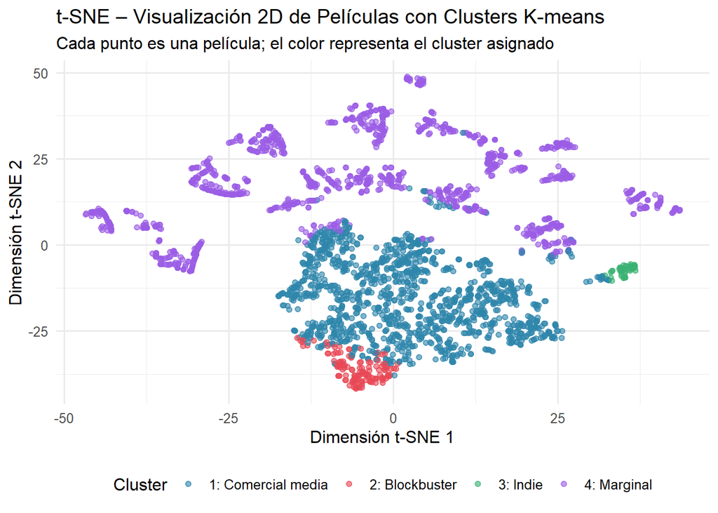

```r
tsne_df <- data.frame(
  X    = tsne_result$Y[, 1],
  Y    = tsne_result$Y[, 2],
  Cluster = factor(clusters_filt)
)

ggplot(tsne_df, aes(x = X, y = Y, color = Cluster)) +
  geom_point(alpha = 0.6, size = 1.5) +
  scale_color_manual(
    values = c("1" = "#2E86AB", "2" = "#E84855", "3" = "#3BB273", "4" = "#9B5DE5"),
    labels = c("1: Comercial media", "2: Blockbuster", "3: Indie", "4: Marginal")
  ) +
  labs(
    title    = "t-SNE – Visualización 2D de Películas con Clusters K-means",
    subtitle = "Cada punto es una película; el color representa el cluster asignado",
    x        = "Dimensión t-SNE 1",
    y        = "Dimensión t-SNE 2",
    color    = "Cluster"
  ) +
  theme_minimal(base_size = 12) +
  theme(legend.position = "bottom")
```